# Data Analysis of EPL 2019/20 Season - The Lockdown Games

### Away statistics of teams

```r
# Summarized multiple statistics for each team playing away
team_away_summary <- team %>%
  group_by(teamId) %>%
  filter(Home_Away  == "a") %>%
  summarise(
    Matches = sum(Home_Away =="a"),
    Wins = sum(ifelse(result == "w", 1, 0)),
    Draws = sum(ifelse(result == "d", 1, 0)),
    Loses = sum(ifelse(result == "l", 1, 0)),
    Goal_Scored = sum(scored),
    Goal_Conceded =  sum(conceded),
    Goal_Differnce = Goal_Scored - Goal_Conceded,
    Points = sum(pts),
    Success = paste0(as.integer((Points / (Matches * 3)) * 100),"%")

  ) %>%
    arrange(desc(Points)) # ordering by points

print(team_away_summary)
```

```
## # A tibble: 20 × 10
##    teamId     Matches  Wins Draws Loses Goal_Scored Goal_Conceded Goal_Differnce
##    <chr>        <int> <dbl> <dbl> <dbl>       <int>         <int>          <int>
##  1 Liverpool       14    12     1     1          26             9             17
##  2 Man City        15     9     1     5          35            19             16
##  3 Chelsea         14     7     3     4          29            24              5
##  4 Leicester       14     7     2     5          28            13             15
##  5 Wolves          14     5     6     3          20            17              3
##  6 Southampt…      14     6     2     6          19            21             -2
##  7 Sheffield…      13     4     7     2          13            12              1
##  8 Crystal P…      14     4     5     5          14            19             -5
##  9 Burnley         14     4     4     6          14            21             -7
## 10 Man Utd         14     4     4     6          15            18             -3
## 11 Tottenham       15     3     6     6          20            25             -5
## 12 Arsenal         13     2     8     3          14            16             -2
## 13 Newcastle…      15     4     2     9          13            29            -16
## 14 Everton         15     3     3     9          18            31            -13
## 15 West Ham        15     3     3     9          12            24            -12
## 16 Brighton        15     2     5     8          15            25            -10
## 17 Bournemou…      15     3     1    11          12            26            -14
## 18 Watford         15     2     4     9          11            27            -16
## 19 Aston Vil…      15     2     2    11          16            32            -16
## 20 Norwich         15     1     3    11           6            26            -20
## # ℹ 2 more variables: Points <int>, Success <chr>
```

*Away Games*: *Liverpool Dominance Continues*: Liverpool also excelled away from home, winning 12 out of 14 matches with an 88% success rate. They maintained a strong goal difference (+17).

*Manchester City’s Away Performance*: Manchester City had a good away record with 9 wins out of 15 matches. They were the highest-scoring team away from home (35 goals).

*Surprising Away Strength*: Southampton performed better away (47% success) compared to their home record. Sheffield United showed strong resilience away with a high number of draws (7 out of 13).

*Poor Away Records*: Norwich, Aston Villa, and Bournemouth had very poor away performances, with Norwich securing only 6 points and having a goal difference of -20. Teams like Watford and Brighton also struggled significantly, with low success rates and negative goal differences.

### Is there any bias in Home and Away Matches?

```r
print(sum(team_home_summary$Matches))
```

```
## [1] 288
```

```r
print(sum(team_away_summary$Matches))
```

```
## [1] 288
```

There is exact number of home and away matches.So, we can consider no biases in our analysis.

Lets have a quick look on teams away and home points with pie chart.

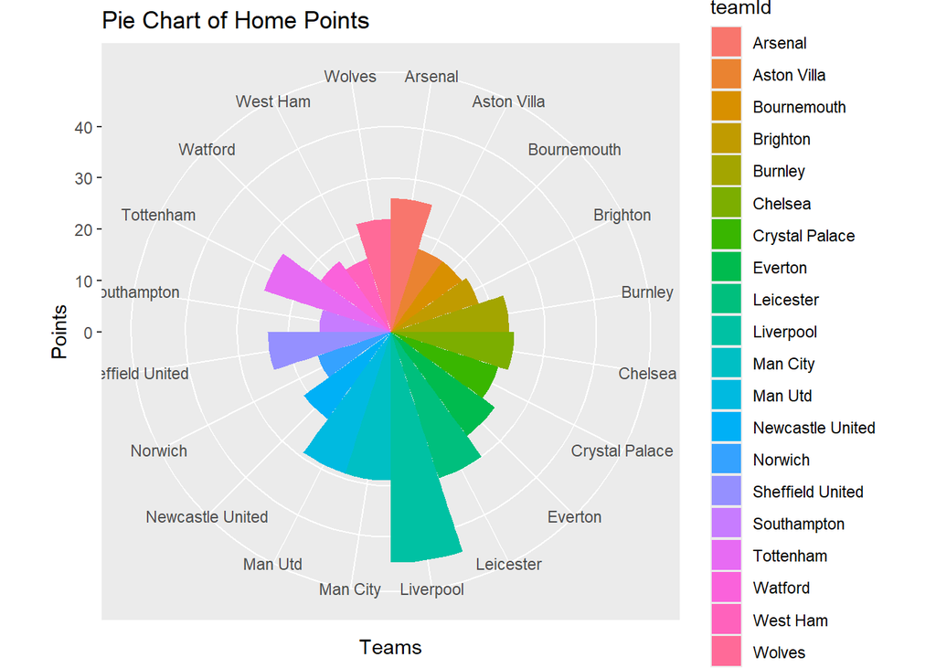

```r
#pie chart to see all teams home points.
pie_home <- ggplot(team_home_summary, aes(x = teamId, y = Points, fill = teamId)) +
  geom_bar(stat = "identity", width = 1) +
  coord_polar("x") +
  labs(title = "Pie Chart of Home Points",x="Teams",y="Points")

print(pie_home)
```

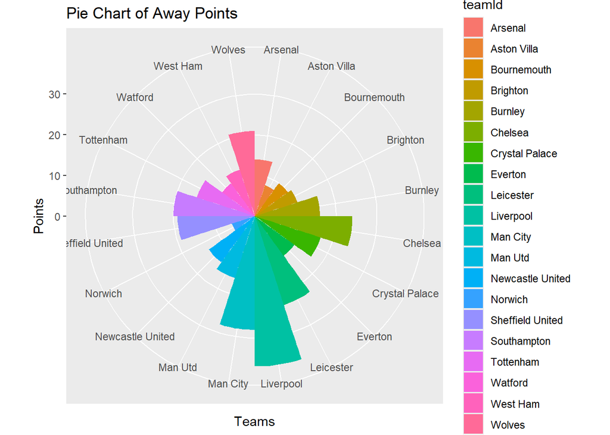

```r
pie_away <- ggplot(team_away_summary, aes(x = teamId, y = Points, fill = teamId)) +
  geom_bar(stat = "identity", width = 1) +
  coord_polar("x") +
  labs(title = "Pie Chart of Away Points",x="Teams",y="Points")

print(pie_away)
```

Both charts gives us a idea that very few team does well in away stadiums.Let’s have a look at overall home and away points.

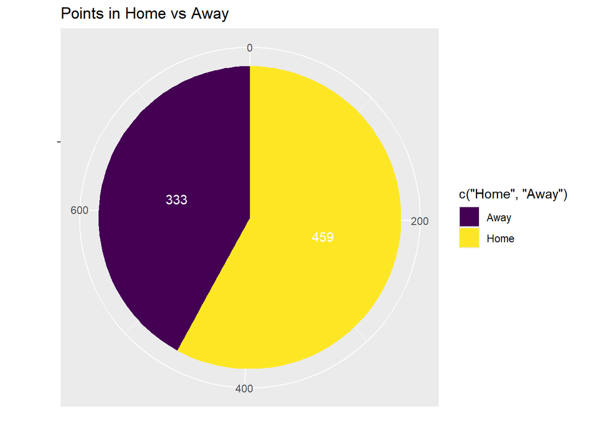

```r
x <- c(
  sum(team$pts[team$Home_Away == "h"]),
  sum(team$pts[team$Home_Away == "a"])
)

pie_away <- ggplot() +
  geom_bar(aes(x = "", y = x, fill = c("Home", "Away")), stat = "identity", width = 1) +
  coord_polar("y") +
  labs(title = "Points in Home vs Away", x = "", y = "") +
  scale_fill_viridis_d() +
  geom_text(aes(x = "", y = x, label = x), position = position_stack(vjust = 0.5),color="white")

print(pie_away)
```

Home teams are generally earned more points than away teams despite playing in closed doors.But overall points doesn’t always shows a teams performance. We could evaluate a teams performance if we could analyse the team offensively and defensively.Expected goals gives us offensive insights of a team.

### Which teams are leading on scoring goals? Home or Away?

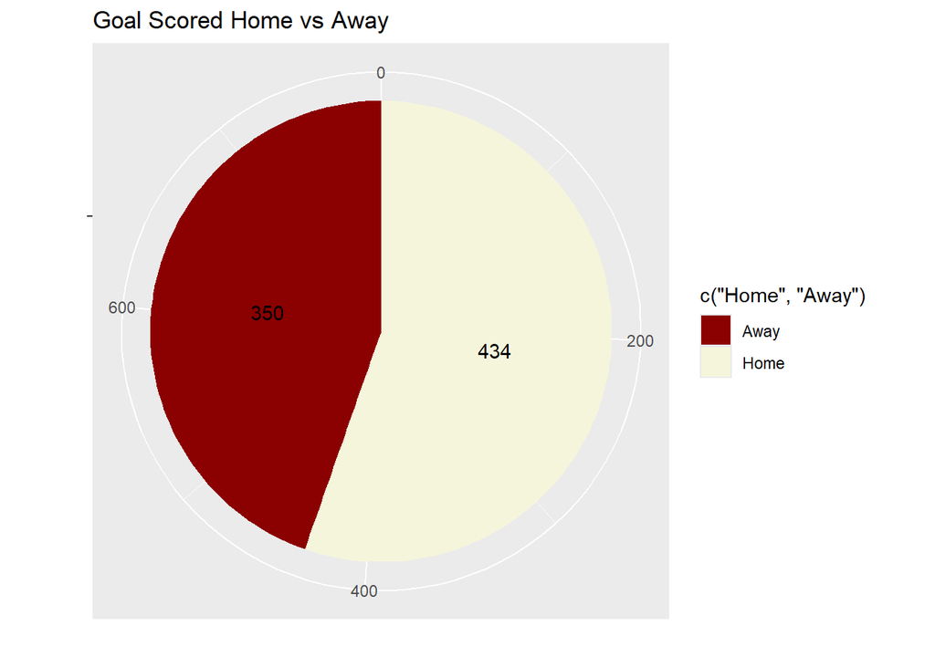

```r
x <- c(
  sum(team$scored[team$Home_Away == "h"]),
  sum(team$scored[team$Home_Away == "a"])
)

pie_away <- ggplot() +
  geom_bar(aes(x = "", y = x, fill = c("Home", "Away")), stat = "identity", width = 1) +
  coord_polar("y") +
  labs(title = "Goal Scored Home vs Away", x = "", y = "") +
  scale_fill_manual(values = c("Home" = "beige", "Away" = "red4")) +
  geom_text(aes(x = "", y = x, label = x), position = position_stack(vjust = 0.5))

print(pie_away)
```

Home team scored more goals meaning away teams are poor in scoring goals.

```r
library(gridExtra)
```

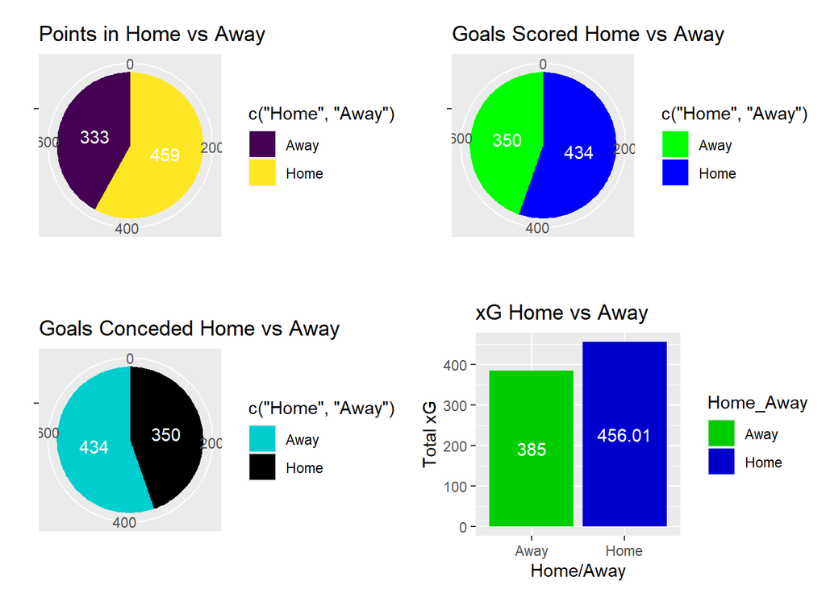

```r
# Home vs Away Points
points_data <- c(
  sum(team$pts[team$Home_Away == "h"]),
  sum(team$pts[team$Home_Away == "a"])
)

  points <- ggplot() +
  geom_bar(aes(x = "", y = points_data, fill = c("Home", "Away")), stat = "identity", width = 1) +
  coord_polar("y") +
  labs(title = "Points in Home vs Away", x = "", y = "") +
  scale_fill_viridis_d() +
  geom_text(aes(x = "", y = points_data, label = points_data), position = position_stack(vjust = 0.5), color = "white")

# Home vs Away Goals Scored
goals_data <- c(
  sum(team$scored[team$Home_Away == "h"]),
  sum(team$scored[team$Home_Away == "a"])
)

  scored <- ggplot() +
  geom_bar(aes(x = "", y = goals_data, fill = c("Home", "Away")), stat = "identity", width = 1) +
  coord_polar("y") +
  labs(title = "Goals Scored Home vs Away", x = "", y = "") +
  scale_fill_manual(values = c("Home" = "blue", "Away" = "green")) +
  geom_text(aes(x = "", y = goals_data, label = goals_data), position = position_stack(vjust = 0.5),color="white")


# Home vs Away Goals conceded
goals_conc <- c(
  sum(team$conceded[team$Home_Away=="h"]),
  sum(team$conceded[team$Home_Away=="a"])
)
  conceded <- ggplot() +
  geom_bar(aes(x = "", y = goals_conc, fill = c("Home", "Away")), stat = "identity", width = 1) +
  coord_polar("y") +
  labs(title = "Goals Conceded Home vs Away", x = "", y = "") +
  scale_fill_manual(values = c("Home" = "black", "Away" = "cyan3")) +
  geom_text(aes(x = "", y = goals_conc, label = goals_conc), position = position_stack(vjust = 0.5),color="white")

# Home vs Away xG
xG_data <- data.frame(
  Home_Away = c("Home", "Away"),
  xG = c(
    sum(team$xG[team$Home_Away == "h"]),
    sum(team$xG[team$Home_Away == "a"])
  )
)

# Create the bar plot using ggplot2
  Expected_Goals <- ggplot(xG_data, aes(x = Home_Away, y = xG, fill = Home_Away)) +
  geom_bar(stat = "identity") +
  labs(title = "xG Home vs Away", x = "Home/Away", y = "Total xG") +
  scale_fill_manual(values = c("Home" = "blue3", "Away" = "green3")) +
  geom_text(aes(label = round(xG, 2)), position = position_stack(vjust = 0.5),color="white")

# Arrange the two pie charts side by side
grid.arrange(points, scored,conceded,Expected_Goals, ncol = 2)
```

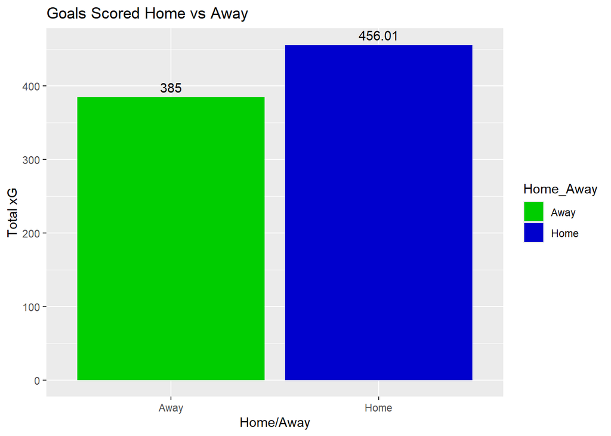

```r
# Calculate xG for Home and Away
xG_data <- data.frame(
  Home_Away = c("Home", "Away"),
  xG = c(
    sum(team$xG[team$Home_Away == "h"]),
    sum(team$xG[team$Home_Away == "a"])
  )
)

# Create the bar plot using ggplot2
ggplot(xG_data, aes(x = Home_Away, y = xG, fill = Home_Away)) +
  geom_bar(stat = "identity") +
  labs(title = "Goals Scored Home vs Away", x = "Home/Away", y = "Total xG") +
  scale_fill_manual(values = c("Home" = "blue3", "Away" = "green3")) +
  geom_text(aes(label = round(xG, 2)), vjust = -0.5)
```